# Time Series Hourly seasonality for January with end destination Schiphol - SARIMAX

```python
#Data handling visualizing and Machine Learning
import numpy as np
import pandas as pd
import warnings
import itertools
import statsmodels
import statsmodels.api as sm
import matplotlib
import matplotlib.pyplot as plt
import seaborn as sns

#Utilities
import datetime
from dateutil import parser #used for parsing datetime columns
from IPython.display import display
from IPython.display import Image #used for displaying images

print('numpy version:', np.__version__)
print('pandas version:', pd.__version__)
print('statsmodels version:', statsmodels.__version__)
print('matplotlib version:', matplotlib.__version__)

%matplotlib inline
```

```
numpy version: 1.20.3
pandas version: 1.3.4
statsmodels version: 0.12.2
matplotlib version: 3.4.3
```

```python
#This data only includes journeys with Schiphol Airport as end destination in January
df = pd.read_csv('January_Schiphol_Time_Groups.csv')
df.shape
```

```
(76315, 16)
```

```python
df = df.drop(columns = ["Unnamed: 0", "Train_Departure_Planned_Time"])
```

## Time Groups constructed around Rush hour

Time_Group is a category that indicates which part of the day the specific train on that row planned to depart, it can have 5 different values:

- 1 Early_Morning (00:00 - 05:59)
- 2 Morning_Rush_Hour (06:00 - 09:59)
- 3 Between_Rush_hours (10:00 - 14:59)
- 4 Afternoon_Rush_hour (15:00 - 18:59)
- 5 Night (19:00 - 24:00)

```python
#I add a time group number
df["Time_Group_Number"] = np.where(df['Time_Group'] == 'Early_Morning', 1,
                          np.where(df['Time_Group'] == 'Morning_Rush_Hour', 2,
                          np.where(df['Time_Group'] == 'Between_Rush_hours', 3,
                          np.where(df['Time_Group'] == 'Afternoon_Rush_hour', 4,
                          np.where(df['Time_Group'] == 'Night', 5, 0)))))
```

```python
df['Train_Departure_Actual'] = df.apply(lambda row: parser.parse(row.Train_Departure_Actual), axis=1)
df['Train_Departure_Planned'] = df.apply(lambda row: parser.parse(row.Train_Departure_Planned), axis=1)
df["day_of_week"] = df["day_of_week"].astype("category")
df["Time_Group"] = df["Time_Group"].astype("category")
df["Train_Type"] = df["Train_Type"].astype("category")
df.dtypes
```

```
Station_Code                         object
Station_Name                         object
Train_Number                          int64
Train_Type                         category
Train_Company                        object
Train_Destination_Planned            object
Train_Destination_Actual             object
Train_Departure_Planned      datetime64[ns]
Train_Departure_Actual       datetime64[ns]
Train_Delay                         float64
MaxNumberOfStops                      int64
weekday                               int64
day_of_week                        category
Time_Group                         category
Time_Group_Number                     int32
dtype: object
```

```python
df.set_index('Train_Departure_Planned', inplace=True)
df
```

| Train_Departure_Planned | Station_Code | Station_Name | Train_Number | Train_Type | Train_Company | Train_Destination_Planned | Train_Destination_Actual | Train_Departure_Actual | Train_Delay | MaxNumberOfStops | weekday | day_of_week | Time_Group | Time_Group_Number |
| --- | --- | --- | --- | --- | --- | --- | --- | --- | --- | --- | --- | --- | --- | --- |
| 2016-01-01 06:44:00 | HRL | Heerlen | 3528 | Intercity | NS | Schiphol Airport | Schiphol Airport | 2016-01-01 06:44:00 | 0.0 | 10 | 4 | Friday | Morning_Rush_Hour | 2 |
| 2016-01-01 06:48:00 | EHV | Eindhoven | 3524 | Intercity | NS | Schiphol Airport | Schiphol Airport | 2016-01-01 06:48:00 | 0.0 | 10 | 4 | Friday | Morning_Rush_Hour | 2 |
| 2016-01-01 07:00:00 | STD | Sittard | 3528 | Intercity | NS | Schiphol Airport | Schiphol Airport | 2016-01-01 07:00:00 | 0.0 | 10 | 4 | Friday | Morning_Rush_Hour | 2 |
| 2016-01-01 07:02:00 | DV | Deventer | 1624 | Intercity | NS | Schiphol Airport | Schiphol Airport | 2016-01-01 07:02:00 | 0.0 | 10 | 4 | Friday | Morning_Rush_Hour | 2 |
| 2016-01-01 07:09:00 | HT | 's-Hertogenbosch | 3524 | Intercity | NS | Schiphol Airport | Schiphol Airport | 2016-01-01 07:09:00 | 0.0 | 10 | 4 | Friday | Morning_Rush_Hour | 2 |
| ... | ... | ... | ... | ... | ... | ... | ... | ... | ... | ... | ... | ... | ... | ... |
| 2016-01-31 22:53:00 | HVS | Hilversum | 1684 | Intercity | NS | Schiphol Airport | Schiphol Airport | 2016-01-31 22:53:00 | 0.0 | 13 | 6 | Sunday | Night | 5 |
| 2016-01-31 23:10:00 | AMF | Amersfoort | 11686 | Intercity | NS | Schiphol Airport | Schiphol Airport | 2016-01-31 23:10:00 | 0.0 | 6 | 6 | Sunday | Night | 5 |
| 2016-01-31 23:40:00 | DVD | Duivendrecht | 11686 | Intercity | NS | Schiphol Airport | Schiphol Airport | 2016-01-31 23:40:00 | 0.0 | 6 | 6 | Sunday | Night | 5 |
| 2016-01-31 23:46:00 | ASDZ | Amsterdam Zuid | 11686 | Intercity | NS | Schiphol Airport | Schiphol Airport | 2016-01-31 23:46:00 | 0.0 | 6 | 6 | Sunday | Night | 5 |
| 2016-01-31 23:23:00 | HVS | Hilversum | 11686 | Intercity | NS | Schiphol Airport | Schiphol Airport | 2016-01-31 23:23:00 | 0.0 | 6 | 6 | Sunday | Night | 5 |

76315 rows × 14 columns

```python
#Here I remove previously found negative delays.
#I change them into 0
df.loc[df.Train_Delay < 0, 'Train_Delay'] = 0
```

```python
# Filter out all features I don't want to use in the SARIMAX algorithm
dftiny = df[['Train_Delay', 'weekday', 'Time_Group_Number']]
```

## Time Groups / Resampling

### 24 Hour groups

I'll try to resample the Time-series data into hourly bins per day.

Since there are 24 hours per day and 31 days in january, the resampling in this way should output around 744 rows*

*(Note: This data for January actually: includes early morning of february 1 does not include early morning of January, so it might impact the number of rows)

```python
# Resample for every hour
dftiny = dftiny.resample('60min').mean()
# Round the time group number because it got averaged out
# by including the zeroth minute of an hour we count it as the previous time group
dftiny['Time_Group_Number'].round(decimals=0)

dftiny.drop(index=['2016-01-01 06:00:00', '2016-02-01 00:00:00'], inplace=True)
dftiny.describe
```

```
<bound method NDFrame.describe of                          Train_Delay  weekday  Time_Group_Number
Train_Departure_Planned
2016-01-01 07:00:00        77.485294      4.0           2.000000
2016-01-01 08:00:00        95.354839      4.0           2.000000
2016-01-01 09:00:00         7.079208      4.0           2.000000
2016-01-01 10:00:00         8.394161      4.0           2.934307
2016-01-01 11:00:00        20.967105      4.0           3.000000
...                              ...      ...                ...
2016-01-31 19:00:00        71.924528      6.0           4.971698
2016-01-31 20:00:00       230.095745      6.0           5.000000
2016-01-31 21:00:00       200.223404      6.0           5.000000
2016-01-31 22:00:00        53.576271      6.0           5.000000
2016-01-31 23:00:00         8.206897      6.0           5.000000

[737 rows x 3 columns]>
```

```python
dftiny["weekday"] = dftiny["weekday"].astype("category")
dftiny["Time_Group_Number"] = dftiny["Time_Group_Number"].astype("category")
dftiny.dtypes
```

```
Train_Delay           float64
weekday              category
Time_Group_Number    category
dtype: object
```

```python
dftiny
```

| Train_Departure_Planned | Train_Delay | weekday | Time_Group_Number |
| --- | --- | --- | --- |
| 2016-01-01 07:00:00 | 77.485294 | 4.0 | 2.000000 |
| 2016-01-01 08:00:00 | 95.354839 | 4.0 | 2.000000 |
| 2016-01-01 09:00:00 | 7.079208 | 4.0 | 2.000000 |
| 2016-01-01 10:00:00 | 8.394161 | 4.0 | 2.934307 |
| 2016-01-01 11:00:00 | 20.967105 | 4.0 | 3.000000 |
| ... | ... | ... | ... |
| 2016-01-31 19:00:00 | 71.924528 | 6.0 | 4.971698 |
| 2016-01-31 20:00:00 | 230.095745 | 6.0 | 5.000000 |
| 2016-01-31 21:00:00 | 200.223404 | 6.0 | 5.000000 |
| 2016-01-31 22:00:00 | 53.576271 | 6.0 | 5.000000 |
| 2016-01-31 23:00:00 | 8.206897 | 6.0 | 5.000000 |

737 rows × 3 columns

As you can see above the result is 737 instead of the planned 744, this is probably because it is missing quite a few hours of data. If you look at the first row the very first hour is 7:00 which matches the amount of rows and therefore hours missing.

```python
dftiny = dftiny[['Train_Delay']]
```

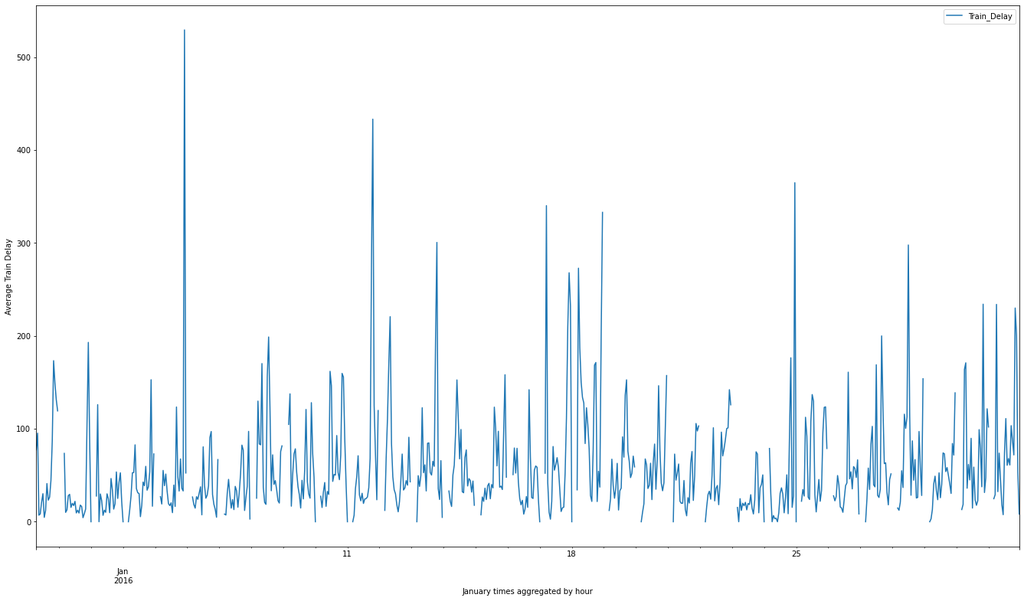

```python
ax = dftiny.plot(figsize=(23,13))
ax.set_xlabel('January times aggregated by hour')
ax.set_ylabel('Average Train Delay')
plt.show()
```

This time we have some missing values.

```python
dftiny = dftiny.fillna(method = 'bfill')
```

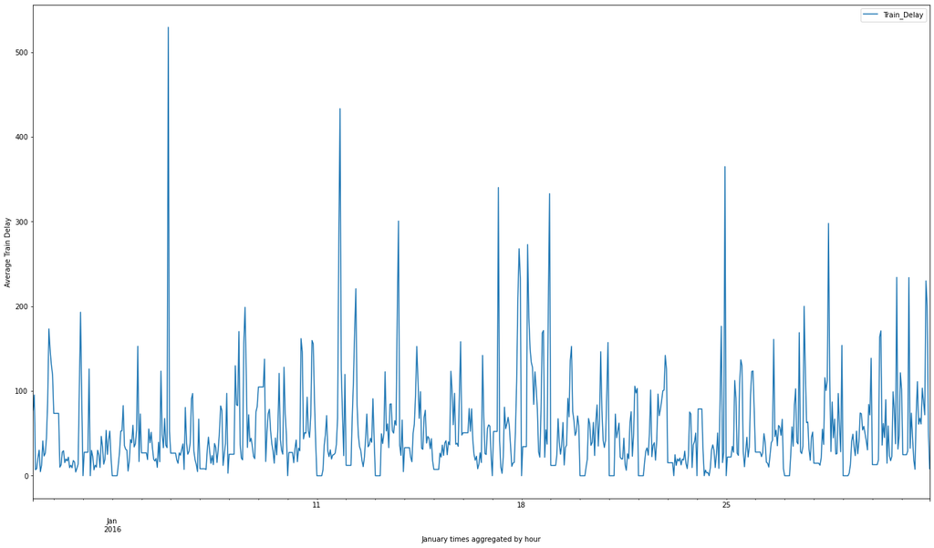

```python
ax = dftiny.plot(figsize=(23,13))
ax.set_xlabel('January times aggregated by hour')
ax.set_ylabel('Average Train Delay')
plt.show()
```

## Seasonality component

- 1 Early_Morning (00:00 - 05:59)
- 2 Morning_Rush_Hour (06:00 - 09:59)
- 3 Between_Rush_hours (10:00 - 14:59)
- 4 Afternoon_Rush_hour (15:00 - 18:59)
- 5 Night (19:00 - 24:00)

With this I can (for example) compare early morning train delays with other early morning train delays. In the end the algorithm will try to find patterns there and attempt to forecast delay duration based on these patterns

```python
# Define the p, d and q parameters to take any value between 0 and 2 (INCREASING THIS MAKES IT TAKE AGES)
p = d = q = range(0, 2)

# Generate all different combinations of p, q and q triplets
# Also called cartesian product (often mentioned in statistics and this field)
pdq = list(itertools.product(p, d, q))

# Generate all different combinations of seasonal p, q and q triplets

seasonal_pdq = [(x[0], x[1], x[2], 24) for x in pdq]

print('Examples of parameter combinations for Seasonal ARIMA...')
print('SARIMAX: {} x {}'.format(pdq[1], seasonal_pdq[1]))
print('SARIMAX: {} x {}'.format(pdq[1], seasonal_pdq[2]))
print('SARIMAX: {} x {}'.format(pdq[2], seasonal_pdq[3]))
print('SARIMAX: {} x {}'.format(pdq[2], seasonal_pdq[4]))
```

```
Examples of parameter combinations for Seasonal ARIMA...
SARIMAX: (0, 0, 1) x (0, 0, 1, 24)
SARIMAX: (0, 0, 1) x (0, 1, 0, 24)
SARIMAX: (0, 1, 0) x (0, 1, 1, 24)
SARIMAX: (0, 1, 0) x (1, 0, 0, 24)
```

**S**ARIMA**X** uses **S**easonality and e**X**ogenous features which ARIMA does not. With patterns like weekdays and rush hours probably having a high impact in train delays it is best if we use SARIMAX.

```python
warnings.filterwarnings("ignore") # specify to ignore warning messages

all_aic = []
best_params = []
for param in pdq:
    for param_seasonal in seasonal_pdq:
        try:
            mod = sm.tsa.statespace.SARIMAX(dftiny,
                                            order=param,
                                            seasonal_order=param_seasonal,
                                            enforce_stationarity=False,
                                            enforce_invertibility=False)

            results = mod.fit()

            #best accuracy values
            all_aic.append(results.aic)
            if(results.aic <= min(all_aic)):
                best_params.clear()
                best_params.append(param)
                best_params.append(param_seasonal)
                best_params.append(results.aic)
            print('SARIMAX{}x{}24 - AIC:{}'.format(param, param_seasonal, results.aic))
        except:
            continue
```

[output not shown]

[output cut: 9 more lines]

[output not shown]

```python
print('As you can see the most accurate hyperparameters are SARIMAX{}x{}5-AIC:{}', best_params[0], best_params[1], best_params[2])
```

```
As you can see the most accurate hyperparameters are SARIMAX{}x{}5-AIC:{} (1, 1, 1) (0, 1, 1, 24) 7393.877645261731
```

SARIMAX(0, 1, 2)x(1, 2, 2, 24)5 - AIC:7015.055967075363 was actually the best when I let it run with p = d = q = range(0,3)

```python
mod = sm.tsa.statespace.SARIMAX(dftiny,
                                order=(0, 1, 2),
                                seasonal_order=(1, 2, 2, 24),
                                enforce_stationarity=False,
                                enforce_invertibility=False)

results = mod.fit()

print(results.summary().tables[1])
```

```
==============================================================================
                 coef    std err          z      P>|z|      [0.025      0.975]
------------------------------------------------------------------------------
ma.L1         -0.6462      0.025    -25.416      0.000      -0.696      -0.596
ma.L2         -0.3236      0.027    -11.876      0.000      -0.377      -0.270
ar.S.L24      -0.0352      0.029     -1.204      0.229      -0.093       0.022
ma.S.L24      -1.9940      4.611     -0.432      0.665     -11.031       7.043
ma.S.L48       0.9890      4.561      0.217      0.828      -7.951       9.929
sigma2      2503.6646   1.15e+04      0.218      0.827      -2e+04     2.5e+04
==============================================================================
```

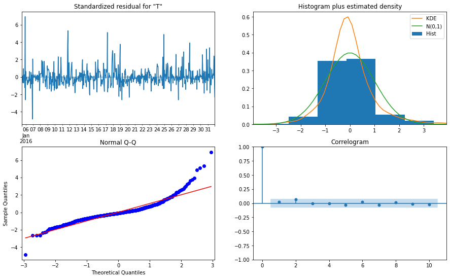

```python
results.plot_diagnostics(figsize=(15, 9))
plt.show()
```

```python
dftiny.sort_index()
```

| Train_Departure_Planned | Train_Delay |
| --- | --- |
| 2016-01-01 07:00:00 | 77.485294 |
| 2016-01-01 08:00:00 | 95.354839 |
| 2016-01-01 09:00:00 | 7.079208 |
| 2016-01-01 10:00:00 | 8.394161 |
| 2016-01-01 11:00:00 | 20.967105 |
| ... | ... |
| 2016-01-31 19:00:00 | 71.924528 |
| 2016-01-31 20:00:00 | 230.095745 |
| 2016-01-31 21:00:00 | 200.223404 |
| 2016-01-31 22:00:00 | 53.576271 |
| 2016-01-31 23:00:00 | 8.206897 |

737 rows × 1 columns

```python
pred = results.get_prediction(start=pd.to_datetime('2016-01-20 07:00:00'), dynamic=False)
pred_ci = pred.conf_int()
```

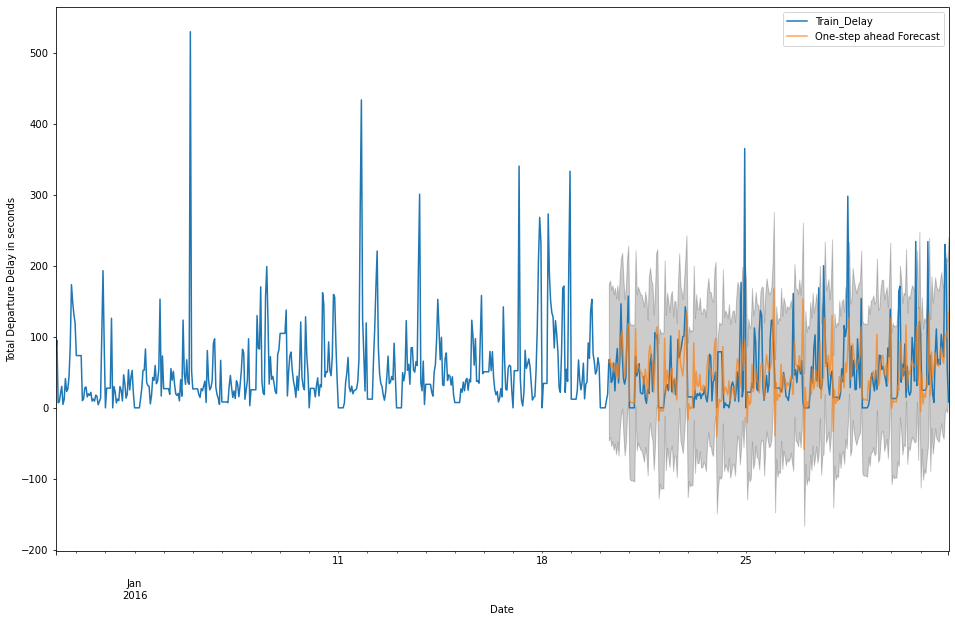

```python
ax = dftiny['2016-01-01 07:00:00':].plot(label='observed', figsize=(16, 10))
pred.predicted_mean.plot(ax=ax, label='One-step ahead Forecast', alpha=.7)

ax.fill_between(pred_ci.index,
                pred_ci.iloc[:, 0],
                pred_ci.iloc[:, 1], color='k', alpha=.2)

ax.set_xlabel('Date')
ax.set_ylabel('Total Departure Delay in seconds')
plt.legend()

plt.show()
```

Below here I'll try to implement a mean squared error. But this is a problem for next iteration.

```python
delay_forecasted = pred.predicted_mean
delay_truth = dftiny['2016-01-20':]

# Compute the mean square error
mse = ((delay_forecasted - delay_truth) ** 2).mean()
# Compute root mean squared error
rms = np.sqrt(mean_squared_error(y_test, y_pred))


print('The Mean Squared Error of our forecasts is {}'.format(round(mse, 2)))
```

[output not shown]

```python
pred_dynamic = results.get_prediction(start=pd.to_datetime('1998-01-01'), dynamic=True, full_results=True)
pred_dynamic_ci = pred_dynamic.conf_int()
```

```python
ax = df_co2['1990':].plot(label='observed', figsize=(20, 15))
pred_dynamic.predicted_mean.plot(label='Dynamic Forecast', ax=ax)

ax.fill_between(pred_dynamic_ci.index,
                pred_dynamic_ci.iloc[:, 0],
                pred_dynamic_ci.iloc[:, 1], color='k', alpha=.25)

ax.fill_betweenx(ax.get_ylim(), pd.to_datetime('1998-01-01'), df_co2.index[-1],
                 alpha=.1, zorder=-1)

ax.set_xlabel('Date')
ax.set_ylabel('CO2 Levels [ppmv]')

plt.legend()
plt.show()
```

[output not shown]